# Homework 6

## Homework 6

### Tharun S

```python
import numpy as np
import pandas as pd
from sklearn.preprocessing import StandardScaler
from sklearn.model_selection import train_test_split
import matplotlib.pyplot as plt
from sklearn import preprocessing
from sklearn.decomposition import PCA
import warnings
warnings.filterwarnings('ignore')
```

### Excercise 1

### Assume that d = 1 and n = 1. The sample is then of size 1 and boils down to just(x,y); the learning parameter β is then a scalar. Write a function that computes the formula of the solution of this minimization problem.

```python
def compute_min_beta(x,y,beta,lamda):
    if 2*x*y > lamda:
        return (2*x*y-lamda)/2*x**2
    elif 2*X*Y < -lamda:
        return (2*x*y+lamda)/2*x**2
    else:
        return 0
```

### Assume now that d > 1 and n > 1. The full minimization problem now writes as

```python
def compute_beta_at_j(X_train,Y_train,j,beta,lamda):
    n = X_train.shape[0]
    d = X_train.shape[1]
    X_minus_j = np.delete(X_train, j, axis=1)
    beta_minus_j = np.delete(beta, j, axis=0)

    R_minus_j = Y_train - (X_minus_j.dot(beta_minus_j))

    X_j = X_train[:,j].reshape(1, n)
    z_j = np.square(np.linalg.norm(X_j, ord=2))

    c_j = (2 / n) * X_j.dot(R_minus_j)
    denominator = (2/n )*z_j

    if c_j <= -lamda:
        beta_j = (lamda + c_j) / denominator
        return beta_j
    elif c_j >= lamda:
        beta_j = (-lamda + c_j) / denominator
        return beta_j
    elif np.abs(c_j) <= lamda:
        beta_j = 0
        return beta_j
```

### Consider the Hitters dataset

```python
hitters = pd.read_csv("https://raw.githubusercontent.com/selva86/datasets/master/Hitters.csv", sep= ",", header=0)
hitters.dropna(inplace = True)
```

```python
hitters = pd.get_dummies(hitters)
X = hitters.drop('Salary',axis = 1)
Y = hitters['Salary']
```

```python
X_train,X_test,Y_train,Y_test = train_test_split(X,Y)

Y_train = Y_train.values.reshape(-1,1)
Y_test = Y_test.values.reshape(-1,1)

#standardizing features
scaler = StandardScaler()
X_train = scaler.fit_transform(X_train)
X_test = scaler.transform(X_test)

#only centering Y
scalerY = StandardScaler(with_std=False)
Y_train = scalerY.fit_transform(Y_train)
Y_test = scalerY.transform(Y_test)
```

### Write a function computeobj that computes and returns F(β) for any β.

```python
def compute_obj(X_train,Y_train,beta,lamda):
    emp_risk = (1/X_train.shape[0])*np.square(np.linalg.norm(Y_train - X_train.dot(beta), ord=2))
    reg_param = lamda * np.linalg.norm(beta, ord=1)
    return emp_risk + reg_param
```

### Write a function cycliccoorddescent that implements the cyclic coordinate descent algorithm. The cyclic coordinate descent algorithm proceeds sequentially. At each iteration, the algorithm increments the index jt of the coordinate to minimize over. Then the algorithm performs partial minimization with respect to the coordinate βjt cor- responding to that index. After updating the coordinate βjt, the algorithm proceeds to the next iteration. The function takes as input the initial point and the maximum number of iterations. The stopping criterion is the maximum number of iterations.

```python
def cycliccoorddescent(X_train,Y_train,lamda,maxIter):
    beta = np.zeros((X_train.shape[1], 1))
    d = X_train.shape[1]
    beta_history = []
    beta_history= np.array(beta)
    cost_history = []
    for i in range(0,maxIter):
        #print(beta)
        j = i % X_train.shape[1]
        beta[j, 0]= compute_beta_at_j(X_train,Y_train,j,beta,lamda)
        if i%d == 0:
            beta_history= np.append(beta_history,beta,axis=1)
            cost_history.append(compute_obj(X_train,Y_train,beta,lamda))
    return beta,beta_history,cost_history
```

### Write a function pickcoord that samples uniformly from the set {1,...,d}

```python
def pickcoord(X_train):
    return np.random.randint(0,X_train.shape[1],size=1)
```

### Write a function randcoorddescent that implements the randomized coordinate descent algorithm.

```python
def randcoorddescent(X_train,Y_train,lamda,maxIter):
    beta = np.zeros((X_train.shape[1], 1))
    d = X_train.shape[1]
    beta_history = []
    beta_history = np.array(beta)
    cost_history = []
    for i in range(0,maxIter):
        j = pickcoord(X_train)
        beta[j, 0]= compute_beta_at_j(X_train,Y_train,j,beta,lamda)
        if i%d == 0:
            beta_history = np.append(beta_history,beta,axis=1)
            cost_history.append(compute_obj(X_train,Y_train,beta,lamda))
    return beta,beta_history,cost_history
```

### Run cross-validation on the training set of the Hitters dataset using scikit-learn to find the optimal value of λ. Run cycliccoorddescent and randcoorddescent on the training set of the Hitters dataset for that value of λ found by cross-validation.

```python
#Cross validation
from sklearn.linear_model import LassoCV
lamda = np.logspace(-4,5,1000)
model = LassoCV(eps=0.001, alphas = lamda, max_iter=1000,
                tol=0.0001, cv= 5, selection= 'cyclic').fit(X_train,Y_train)
```

```python
#calculating optimal lambda
alpha = model.alpha_
alpha = lamda[np.argmin(np.mean(model.mse_path_ , axis=1))]
```

[output not shown]

```python
#Random coordinated descent
d=X_train.shape[1]
beta_r,beta_his_r,cost_his_r = randcoorddescent(X_train,Y_train,alpha*2,1000)
```

```python
#Cyclic coordinated descent
beta,beta_his,cost_his = cycliccoorddescent(X_train,Y_train,alpha*2,1000)
```

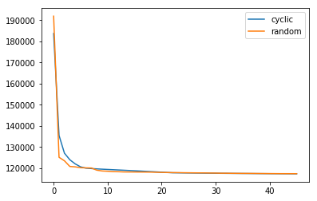

```python
#Plotting cost for both types of algorithms
plt.plot(np.arange(0,len(cost_his)),cost_his,label = 'cyclic')
plt.plot(np.arange(0,len(cost_his_r)),cost_his_r, label = 'random')
plt.legend();
```

#### We find that the random coordinate descent converges slightly faster compared to cyclic coordinate descent. The cost after 40 iterations is almost equal for both types of coordinate descent algorithm

### Denote by βT the final iterates of your coordinate descent algorithms for that valueof λ. Compute β* found by scikit-learn for that value of λ.

```python
#Computing β* using sci-kit
from sklearn.linear_model import Lasso
cyclic = Lasso(alpha = alpha, max_iter=1000/X_train.shape[1],selection='cyclic')
cyclic.fit(X_train,Y_train)
beta_cyclic_sc = cyclic.coef_
random = Lasso(alpha = alpha, max_iter=1000/X_train.shape[1], selection= 'random')
random.fit(X_train,Y_train)
beta_random_sc = random.coef_
```

```python
pd.DataFrame({'cyclic' : beta.flatten(), 'sk_cyclic': beta_cyclic_sc.flatten(), 'random' : beta_r.flatten(),
              'sk_random' : beta_random_sc.flatten()})
```

|  | cyclic | sk_cyclic | random | sk_random |
| --- | --- | --- | --- | --- |
| 0 | -5.530710e+01 | -5.530784e+01 | -53.280268 | -40.870652 |
| 1 | 1.178154e+02 | 1.177173e+02 | 119.389661 | 107.192397 |
| 2 | -1.440578e+01 | -1.453911e+01 | -10.214510 | -10.196942 |
| 3 | 0.000000e+00 | 0.000000e+00 | 0.000000 | 0.000000 |
| 4 | 0.000000e+00 | 0.000000e+00 | 0.000000 | 0.000000 |
| 5 | 3.930065e+01 | 3.944117e+01 | 36.387728 | 34.173548 |
| 6 | -3.229571e+01 | -3.249022e+01 | -21.877871 | -25.742392 |
| 7 | 0.000000e+00 | 0.000000e+00 | 0.000000 | 0.000000 |
| 8 | 6.903821e+01 | 7.120702e+01 | 48.736371 | 38.531293 |
| 9 | 6.803040e+01 | 6.942585e+01 | 43.335885 | 39.436054 |
| 10 | 1.476570e+01 | 1.476570e+01 | 0.000000 | 9.458872 |
| 11 | 1.104068e+02 | 1.104068e+02 | 146.381064 | 154.737868 |
| 12 | -1.260035e+01 | -1.260035e+01 | 0.000000 | -0.000000 |
| 13 | 6.938728e+01 | 6.938728e+01 | 68.820335 | 69.097381 |
| 14 | 0.000000e+00 | 0.000000e+00 | 0.000000 | 0.000000 |
| 15 | -1.027395e+01 | -1.027395e+01 | -10.782251 | -11.492226 |
| 16 | -4.246149e+00 | -4.246149e+00 | -3.246941 | -1.282196 |
| 17 | 0.000000e+00 | 1.038763e-14 | 0.939437 | 2.971900 |
| 18 | 6.262812e+01 | 6.262812e+01 | 0.822065 | 63.082043 |
| 19 | -5.933032e-13 | -8.033100e-13 | -62.397084 | -0.256158 |
| 20 | 0.000000e+00 | -0.000000e+00 | 0.000000 | -0.000000 |
| 21 | 0.000000e+00 | 0.000000e+00 | 0.000000 | 0.000000 |

### Plot the curves of the fraction of correct non-zero/zero coefficients (with respect to β*) for both algorithms versus the iteration counter iter

```python
#sci kit non zero and zero coefficients
sk_non_zero_random = np.sum(beta_random_sc!=0)
sk_non_zero_cyclic = np.sum(beta_cyclic_sc!=0)
sk_zero_random = np.sum(beta_random_sc==0)
sk_zero_cyclic = np.sum(beta_cyclic_sc==0)
```

```python
#non-zero coefficients from own algorithm
non_zero_beta_random = []
non_zero_beta_cyclic = []
d = X_train.shape[1]
for i in range(0,1000//d):
    non_zero_beta_random.append(np.sum(beta_his_r.T[i]!=0)/sk_non_zero_cyclic)
for i in range(0,1000//d):
    non_zero_beta_cyclic.append(np.sum(beta_his.T[i]!=0)/sk_non_zero_random)
```

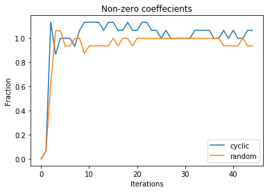

```python
plt.plot(np.arange(0,len(non_zero_beta_cyclic)),non_zero_beta_cyclic, label = 'cyclic')
plt.plot(np.arange(0,len(non_zero_beta_random)),non_zero_beta_random,label = 'random')
plt.ylabel("Fraction")
plt.xlabel("Iterations")
plt.title("Non-zero coeffecients")
plt.legend();
```

```python
#zero coefficients for own algorithm
zero_beta_random = []
zero_beta_cyclic = []
for i in range(0,1000//d):
    zero_beta_random.append(np.sum(beta_his_r.T[i]==0)/sk_zero_cyclic)
for i in range(0,1000//d):
    zero_beta_cyclic.append(np.sum(beta_his.T[i]==0)/sk_zero_random)
```

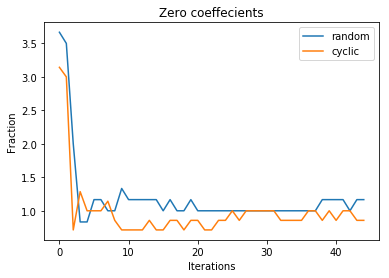

```python
plt.plot(np.arange(0,len(zero_beta_random)),zero_beta_random,label = 'random')
plt.plot(np.arange(0,len(zero_beta_cyclic)),zero_beta_cyclic, label = 'cyclic')
plt.title("Zero coeffecients")
plt.ylabel("Fraction")
plt.xlabel("Iterations")
plt.legend();
```

## Exercise 2

### Generate a simulated data set with 30 observations in each of three classes (i.e. 90 observations total), and 60 features.

```python
data = []
for j in range(30):
    data.append(np.random.normal(1,1,60))
for j in range(30):
    data.append(np.random.normal(50,5,60))
for j in range(30):
    data.append(np.random.normal(150,5,60))
data_centered = data - np.mean(data,axis=0)
```

### Run your own normalized Oja algorithmon the 90 observations. Plot the first two principal component score vectors. Compare your results to the ones obtained with scikit-learn’s PCA algorithm.

```python
def normalized_oja(X ,eta, maxIter):
    n = X.shape[1]
    w_0 = np.ones((n,1))
    w_0 = w_0/np.sqrt(n)
    #print(np.linalg.norm(w_0,ord=2))
    for i in range(maxIter):
        w_t = w_0 + eta*np.dot(np.dot(X.T,X),w_0)
        w_t = w_t/np.linalg.norm(w_t,ord=2)
        w_0 = w_t
    return w_t
```

```python
def get_eigen_value(X,w):
    cov = np.cov(X.T)
    eigen_value = (w.T.dot(np.dot(cov,w)))/w.T.dot(w)
    return eigen_value
```

```python
#Own algorithm OJA
X = np.array(data_centered)
#Compute first eigen vector,value
eigenVector_1 = normalized_oja(X,0.1,1000)
eigenValue_1 = get_eigen_value(X,eigvec1)
#compute second eigen vector,value
X_new = X - X.dot(np.dot(eigenVector_1,eigenVector_1.T))
eigenVector_2 = normalized_oja(X_new, 0.1, 1000)
eigenValue_2 = get_eigen_value(X_new,eigenVector_2)
```

```python
#Sci-kit PCA
pca = PCA(n_components=2)
y = pca.fit(X)
sk_eigenVector_1= pca.components_[0]
sk_eigenVector_2 = pca.components_[1]
classes = ["red"]*30 + ["green"]*30 + ["blue"]*30
```

```python
eigenValues = pd.DataFrame({"oja": [eigenValue_1[0],eigenValue_2[0]],"scikit":pca.explained_variance_})
print("Eigen values")
print(eigenValues)
eigenVectors = pd.DataFrame({"oja_v1":eigenVector_1.reshape(1,-1)[0],"sk_v1":sk_eigenVector_1,
                  "oja_v2":eigenVector_2.reshape(1,-1)[0],"sk_v2":sk_eigenVector_2})
print("\nEigen vectors")
eigenVectors
```

```
Eigen values
                    oja         scikit
0   [233029.1930287557]  233050.237770
1  [62.104858930129836]      62.104859

Eigen vectors
```

|  | oja_v1 | sk_v1 | oja_v2 | sk_v2 |
| --- | --- | --- | --- | --- |
| 0 | 0.127293 | 0.127293 | 0.053143 | 0.053143 |
| 1 | 0.128714 | 0.128714 | 0.048029 | 0.048029 |
| 2 | 0.131138 | 0.131138 | -0.150114 | -0.150114 |
| 3 | 0.128963 | 0.128963 | -0.107684 | -0.107684 |
| 4 | 0.128224 | 0.128224 | -0.055016 | -0.055016 |
| 5 | 0.128998 | 0.128998 | -0.148320 | -0.148320 |
| 6 | 0.130189 | 0.130189 | 0.142481 | 0.142481 |
| 7 | 0.129931 | 0.129931 | -0.209600 | -0.209600 |
| 8 | 0.128150 | 0.128150 | -0.228453 | -0.228453 |
| 9 | 0.129595 | 0.129595 | 0.247351 | 0.247351 |
| 10 | 0.129588 | 0.129588 | -0.077976 | -0.077976 |
| 11 | 0.129064 | 0.129064 | -0.156930 | -0.156930 |
| 12 | 0.129506 | 0.129506 | -0.142449 | -0.142449 |
| 13 | 0.129876 | 0.129876 | -0.077615 | -0.077615 |
| 14 | 0.128852 | 0.128852 | -0.061543 | -0.061543 |
| 15 | 0.130176 | 0.130176 | 0.038495 | 0.038495 |
| 16 | 0.129797 | 0.129797 | 0.067591 | 0.067591 |
| 17 | 0.129442 | 0.129442 | 0.012393 | 0.012393 |
| 18 | 0.129534 | 0.129534 | -0.086486 | -0.086486 |
| 19 | 0.128163 | 0.128163 | -0.150035 | -0.150035 |
| 20 | 0.128600 | 0.128600 | 0.025456 | 0.025456 |
| 21 | 0.129791 | 0.129791 | 0.039108 | 0.039108 |
| 22 | 0.129368 | 0.129368 | -0.104627 | -0.104627 |
| 23 | 0.127122 | 0.127122 | 0.167967 | 0.167967 |
| 24 | 0.129489 | 0.129489 | 0.009997 | 0.009997 |
| 25 | 0.128604 | 0.128604 | -0.156376 | -0.156376 |
| 26 | 0.128157 | 0.128157 | -0.185001 | -0.185001 |
| 27 | 0.128001 | 0.128001 | 0.199766 | 0.199766 |
| 28 | 0.129320 | 0.129320 | 0.013799 | 0.013799 |
| 29 | 0.129054 | 0.129054 | 0.090658 | 0.090658 |
| 30 | 0.129906 | 0.129906 | 0.147544 | 0.147544 |
| 31 | 0.129526 | 0.129526 | 0.171619 | 0.171619 |
| 32 | 0.130591 | 0.130591 | -0.115823 | -0.115823 |
| 33 | 0.128664 | 0.128664 | 0.010666 | 0.010666 |
| 34 | 0.129279 | 0.129279 | -0.219892 | -0.219892 |
| 35 | 0.127080 | 0.127080 | 0.033229 | 0.033229 |
| 36 | 0.127186 | 0.127186 | 0.070404 | 0.070404 |
| 37 | 0.127443 | 0.127443 | 0.032350 | 0.032350 |
| 38 | 0.129185 | 0.129185 | 0.000189 | 0.000189 |
| 39 | 0.129649 | 0.129649 | -0.199945 | -0.199945 |
| 40 | 0.129357 | 0.129357 | 0.132340 | 0.132340 |
| 41 | 0.129313 | 0.129313 | 0.149365 | 0.149365 |
| 42 | 0.129551 | 0.129551 | -0.309508 | -0.309508 |
| 43 | 0.129226 | 0.129226 | 0.196915 | 0.196915 |
| 44 | 0.128843 | 0.128843 | 0.033639 | 0.033639 |
| 45 | 0.127884 | 0.127884 | 0.101248 | 0.101248 |
| 46 | 0.128815 | 0.128815 | 0.158747 | 0.158747 |
| 47 | 0.128882 | 0.128882 | 0.090466 | 0.090466 |
| 48 | 0.129654 | 0.129654 | 0.138840 | 0.138840 |
| 49 | 0.128922 | 0.128922 | -0.053798 | -0.053798 |
| 50 | 0.130027 | 0.130027 | -0.198862 | -0.198862 |
| 51 | 0.129177 | 0.129177 | 0.021440 | 0.021440 |
| 52 | 0.129887 | 0.129887 | 0.108095 | 0.108095 |
| 53 | 0.129108 | 0.129108 | 0.192121 | 0.192121 |
| 54 | 0.128747 | 0.128747 | 0.098453 | 0.098453 |
| 55 | 0.129247 | 0.129247 | 0.036976 | 0.036976 |
| 56 | 0.129896 | 0.129896 | 0.047797 | 0.047797 |
| 57 | 0.128831 | 0.128831 | -0.024692 | -0.024692 |
| 58 | 0.129506 | 0.129506 | 0.006089 | 0.006089 |
| 59 | 0.129725 | 0.129725 | 0.092500 | 0.092500 |

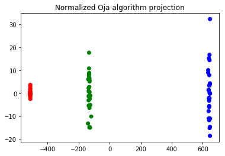

```python
#Calculating projection for oja algorithm
v = np.hstack((eigenVector_1.reshape(-1,1),eigenVector_2.reshape(-1,1)))
proj = v.T.dot(X.T)
color = ["red"] * 30
color.extend(["green"]*30)
color.extend(["blue"]*30)
plt.scatter(proj.T[:,0],proj.T[:,1],c=color)
plt.title("Normalized Oja algorithm projection")
```

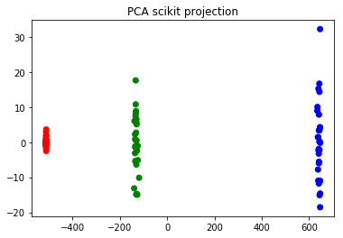

```python
#Projection using PCA
v = np.hstack((sk_eigenVector_1.reshape(-1,1),sk_eigenVector_2.reshape(-1,1)))
proj = v.T.dot(X.T)
color = ["red"] * 30
color.extend(["green"]*30)
color.extend(["blue"]*30)
plt.scatter(proj.T[:,0],proj.T[:,1],c=color)
plt.title("PCA scikit projection")
```

## Excercise 3

### In this exercise, we will generate simulated data, and will then use this data to fit a lasso model. You should use Scikit-learn in this exercise for fitting the lasso model and performing cross-validation.

#### - Use the numpy.random.normal() function to generate a predictor X of lengthn= 100,as well as a noise vector of length n= 100.

```python
X = np.random.normal(100,5,size = 100)
eps = np.random.normal(0.01,0.002,size = 100)
```

```python
beta0,beta1,beta2,beta3,beta7 = 1,15,10,5,10
```

#### - Generate a response vector Y of length n= 100 according to the model

```python
Y = eps + beta0 + beta1*X + beta2*(X**2) + beta3*(X**3)
# Y2 = β0+β7* X^7+e
Y2 = eps + beta0 +  beta7*(X**7)
```

#### - Now fit a lasso model to the simulated data, using X,X2,...,X10 as predictors. Use cross-validation to select the optimal value of λ. Create plots of the cross-validation error as a function of λ. Report the resulting coefficient estimates, and discuss the results obtained.

```python
#Standardize X
X_new = np.array([X**i for i in range(1,11)])
X_new = np.asmatrix(X_new.T)
X_new = scaler.fit_transform(X_new)
#Center Y
Y = scalerY.fit_transform(Y.reshape(-1,1))
Y2 = scalerY.fit_transform(Y2.reshape(-1,1))
```

```python
lamda = np.linspace(1e-10,1000,1000)
```

```python
model = LassoCV(eps=0.001, alphas = lamda, max_iter=1000,
                tol=0.0001, cv= 5).fit(X_new,Y)
print("Optimal lambda ",model.alpha_)
```

```
Optimal lambda  363.363363363427
```

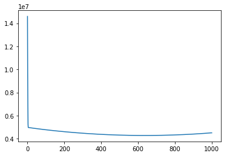

```python
plt.plot(lamda,np.mean(model.mse_path_,axis =1))
```

```python
cyclic = Lasso(alpha = 363.363363363427, max_iter=1000,selection='random',fit_intercept=False).fit(X_new,Y)
cyclic.coef_
```

```
array([1.79833598e+01, 4.02872836e-01, 7.60206432e+05, 0.00000000e+00,
       0.00000000e+00, 0.00000000e+00, 0.00000000e+00, 0.00000000e+00,
       0.00000000e+00, 0.00000000e+00])
```

#### We find the co-effecients for X, X^2, X^3 to be positive and non-zero. This is expected since the response Y is dependent on these predictors. Co-efficient of X^3 has the highest co-efficient, this can be explained by the fact that X^3 has the highest spread or variance and is more significant

#### - Now generate a response vector Y according to the model Y = β0+β7* X^7+, and fit a lasso model. Discuss the results obtained

```python
model = LassoCV(eps=0.001, alphas = lamda, max_iter=1000,
                tol=0.0001, cv= 5).fit(X_new,Y2)
```

```python
mod = Lasso(alpha = 999, max_iter=1000, selection= 'random').fit(X_new,Y2)
mod.coef_
```

```
array([0.00000000e+00, 0.00000000e+00, 0.00000000e+00, 0.00000000e+00,
       0.00000000e+00, 0.00000000e+00, 3.56706691e+14, 0.00000000e+00,
       0.00000000e+00, 0.00000000e+00])
```

#### We find that the coefficient for X^7 to be non-zero. This is in accordance with the model which is dependent on only X^7. The co-efficient is also very high which can be attributed to the spread of the variable X^7